```python
import pandas as pd
import numpy as np
import glob
import os
import warnings

warnings.filterwarnings("ignore")
```

```python
from sklearn.model_selection import train_test_split
import matplotlib.pyplot as plt

def train_test(df,stratify):
    if df.shape[0]<600:
        size=0.45
    else:
        size=0.33
    y=df.iloc[:,-1]
    x=df.drop(columns=[y.name])
    x_train, x_test, y_train, y_test = train_test_split(x, y, test_size=size, random_state=0, stratify=stratify)
    return x_train, x_test, y_train, y_test

def object_features(df):
    return list(df.loc[:,df.dtypes=='object'].columns)

def numeric_features(df):
    return list(df.loc[:,(df.dtypes=='int64')|(df.dtypes=='float64')].columns)


def category_features(df,threshold1,threshold2=0):
    category_features = []
    for each in df.columns:
        if threshold2 < df[each].nunique() < threshold1:
            category_features.append(each)
    return category_features

def check_type(y):
    try:
        condition=y.nunique()
    except:
        condition=len(np.unique(y))
    if condition==2:
        return 'Classification'
    if 2<condition<10:
        return 'Multi-Class Classification'
    else:
        return 'Regression'

def check_imbalance(y):
    if check_type(y)!='Regression':
        return pd.concat([y.value_counts(),y.value_counts(normalize=True)],axis=1)

def check_missing_value(df):
    return any(df.isna().sum()!=0)

def information_table(df):
    number_instance = df.shape[0]
    number_feature  = df.shape[1]

    x_train, x_test, y_train, y_test= train_test(df,None)
    train_instance = x_train.shape[0]
    test_instance  = x_test.shape[0]

    y_type = check_type(y_train)

    number_numeric  = len(numeric_features(x_train))
    number_object   = len(object_features(x_train))

    missing_value = check_missing_value(x_train)

    imbalance = check_imbalance(y_train)

    print('Dataset has ' + str(number_instance) + ' instances and ' + str(number_feature) + ' features.')
    print('After we train test split;')
    print('Training data has ' + str(train_instance) + ' instances and testing data has ' + str(test_instance) + ' instances.')
    print('Class Type is ' + y_type +'.')
    print('Data has ' + str(number_numeric) + ' numeric and ' + str(number_object) + ' object features.')
    if missing_value:
        print('Data has missing value.')
    else:
        print('Data has no missing value.')
    if y_type != 'Regression':
        print('Lets examine imbalance:')
        return imbalance
    else:
        plt.hist(y_train)
        plt.title('Histogram ' + y_train.name)
```

# Datasets

## Informations about the datasets

### Students Performance Data

For more information visit http://archive.ics.uci.edu/ml/datasets/Student+Performance.

Purpose: Regression

```python
os.chdir('C:/Users/Ozan Ozturk/Desktop/Files/HW4/data/Student')
files=glob.glob('*')
df1=pd.read_csv(files[1],delimiter=";")

df1
```

|  | school | sex | age | address | famsize | Pstatus | Medu | Fedu | Mjob | Fjob | ... | famrel | freetime | goout | Dalc | Walc | health | absences | G1 | G2 | G3 |
| --- | --- | --- | --- | --- | --- | --- | --- | --- | --- | --- | --- | --- | --- | --- | --- | --- | --- | --- | --- | --- | --- |
| 0 | GP | F | 18 | U | GT3 | A | 4 | 4 | at_home | teacher | ... | 4 | 3 | 4 | 1 | 1 | 3 | 4 | 0 | 11 | 11 |
| 1 | GP | F | 17 | U | GT3 | T | 1 | 1 | at_home | other | ... | 5 | 3 | 3 | 1 | 1 | 3 | 2 | 9 | 11 | 11 |
| 2 | GP | F | 15 | U | LE3 | T | 1 | 1 | at_home | other | ... | 4 | 3 | 2 | 2 | 3 | 3 | 6 | 12 | 13 | 12 |
| 3 | GP | F | 15 | U | GT3 | T | 4 | 2 | health | services | ... | 3 | 2 | 2 | 1 | 1 | 5 | 0 | 14 | 14 | 14 |
| 4 | GP | F | 16 | U | GT3 | T | 3 | 3 | other | other | ... | 4 | 3 | 2 | 1 | 2 | 5 | 0 | 11 | 13 | 13 |
| ... | ... | ... | ... | ... | ... | ... | ... | ... | ... | ... | ... | ... | ... | ... | ... | ... | ... | ... | ... | ... | ... |
| 644 | MS | F | 19 | R | GT3 | T | 2 | 3 | services | other | ... | 5 | 4 | 2 | 1 | 2 | 5 | 4 | 10 | 11 | 10 |
| 645 | MS | F | 18 | U | LE3 | T | 3 | 1 | teacher | services | ... | 4 | 3 | 4 | 1 | 1 | 1 | 4 | 15 | 15 | 16 |
| 646 | MS | F | 18 | U | GT3 | T | 1 | 1 | other | other | ... | 1 | 1 | 1 | 1 | 1 | 5 | 6 | 11 | 12 | 9 |
| 647 | MS | M | 17 | U | LE3 | T | 3 | 1 | services | services | ... | 2 | 4 | 5 | 3 | 4 | 2 | 6 | 10 | 10 | 10 |
| 648 | MS | M | 18 | R | LE3 | T | 3 | 2 | services | other | ... | 4 | 4 | 1 | 3 | 4 | 5 | 4 | 10 | 11 | 11 |

649 rows × 33 columns

```
Dataset has 649 instances and 33 features.
After we train test split;
Training data has 434 instances and testing data has 215 instances.
Class Type is Regression.
Data has 15 numeric and 17 object features.
Data has no missing value.
```

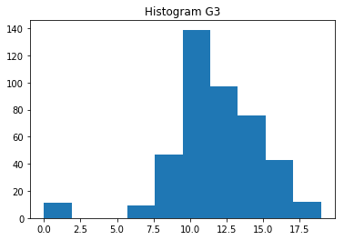

```python
information_table(df1)
```

### Residential Building Data

For more information visit http://archive.ics.uci.edu/ml/datasets/Residential+Building+Data+Set.

Purpose: Regression

```python
url='http://archive.ics.uci.edu/ml/machine-learning-databases/00437/Residential-Building-Data-Set.xlsx'
df2=pd.read_excel(url,skiprows=1)
variable_names=pd.read_excel(url,sheet_name=1)[['Variable ID  ', 'Descriptions']].dropna()

variable_names
```

|  | Variable ID | Descriptions |
| --- | --- | --- |
| 0 | V-1 | Project locality defined in terms of zip codes |
| 1 | V-2 | Total floor area of the building |
| 2 | V-3 | Lot area |
| 3 | V-4 | Total preliminary estimated construction cost ... |
| 4 | V-5 | Preliminary estimated construction cost based ... |
| 5 | V-6 | Equivalent preliminary estimated construction ... |
| 6 | V-7 | Duration of construction |
| 7 | V-8 | Price of the unit at the beginning of the proj... |
| 8 | V-9 | Actual sales prices (output) |
| 9 | V-10 | Actual construction costs (output) |
| 10 | V-11 | The number of building permits issued |
| 11 | V-12 | Building services index (BSI) b for a preselec... |
| 12 | V-13 | Wholesale price index (WPI) c of building mate... |
| 13 | V-14 | Total floor areas of building permits issued b... |
| 14 | V-15 | Cumulative liquidity d |
| 15 | V-16 | Private sector investment in new buildings |
| 16 | V-17 | Land price index for the base year a |
| 17 | V-18 | The number of loans extended by banks in a tim... |
| 18 | V-19 | The amount of loans extended by banks in a tim... |
| 19 | V-20 | The interest rate for loan in a time resolution e |
| 20 | V-21 | The average construction cost of buildings by ... |
| 21 | V-22 | The average of construction cost of buildings ... |
| 22 | V-23 | Official exchange rate with respect to dollars |
| 23 | V-24 | Nonofficial (street market) exchange rate with... |
| 24 | V-25 | Consumer price index (CPI) i in the base year a |
| 25 | V-26 | CPI of housing, water, fuel & power in the bas... |
| 26 | V-27 | Stock market index j |
| 27 | V-28 | Population of the city |
| 28 | V-29 | Gold price per ounce |

The data contain two output variables. (V-9 , V-10) For simplicity V-10 columns is removed.

```python
df2.drop(columns='V-10', inplace=True)

df2
```

|  | START YEAR | START QUARTER | COMPLETION YEAR | COMPLETION QUARTER | V-1 | V-2 | V-3 | V-4 | V-5 | V-6 | ... | V-21.4 | V-22.4 | V-23.4 | V-24.4 | V-25.4 | V-26.4 | V-27.4 | V-28.4 | V-29.4 | V-9 |
| --- | --- | --- | --- | --- | --- | --- | --- | --- | --- | --- | --- | --- | --- | --- | --- | --- | --- | --- | --- | --- | --- |
| 0 | 81 | 1 | 85 | 1 | 1 | 3150.0 | 920.0 | 598.5 | 190 | 1010.84 | ... | 733.800000 | 815.50 | 1755.00 | 8002.0 | 60.74 | 54.26 | 2978.26 | 41407.00 | 601988.1 | 2200 |
| 1 | 84 | 1 | 89 | 4 | 1 | 7600.0 | 1140.0 | 3040.0 | 400 | 963.81 | ... | 1143.800000 | 1316.30 | 8364.78 | 8393.0 | 90.95 | 89.79 | 11379.37 | 44835.00 | 929027.1 | 5000 |
| 2 | 78 | 1 | 81 | 4 | 1 | 4800.0 | 840.0 | 480.0 | 100 | 689.84 | ... | 589.500000 | 765.80 | 1755.00 | 4930.0 | 38.70 | 32.04 | 1653.06 | 37933.00 | 377828.6 | 1200 |
| 3 | 72 | 2 | 73 | 2 | 1 | 685.0 | 202.0 | 13.7 | 20 | 459.54 | ... | 197.679557 | 152.25 | 1442.31 | 1456.0 | 9.73 | 8.34 | 686.16 | 8194.00 | 122031.7 | 165 |
| 4 | 87 | 1 | 90 | 2 | 1 | 3000.0 | 800.0 | 1230.0 | 410 | 631.91 | ... | 2220.600000 | 2244.10 | 9231.76 | 9286.0 | 136.60 | 140.20 | 9821.00 | 48260.00 | 1734973.5 | 5500 |
| ... | ... | ... | ... | ... | ... | ... | ... | ... | ... | ... | ... | ... | ... | ... | ... | ... | ... | ... | ... | ... | ... |
| 367 | 83 | 4 | 86 | 1 | 20 | 1350.0 | 350.0 | 108.0 | 80 | 251.37 | ... | 1082.500000 | 1176.50 | 8343.60 | 8382.0 | 87.27 | 85.56 | 10555.47 | 33626.25 | 865878.9 | 1100 |
| 368 | 81 | 2 | 82 | 4 | 20 | 600.0 | 150.0 | 36.0 | 60 | 299.55 | ... | 746.800000 | 815.50 | 1755.00 | 8013.0 | 62.78 | 56.45 | 3387.72 | 10646.75 | 606524.2 | 740 |
| 369 | 84 | 4 | 86 | 3 | 20 | 1900.0 | 430.0 | 285.0 | 150 | 364.41 | ... | 1424.100000 | 1584.30 | 8776.71 | 8799.0 | 101.00 | 101.89 | 13571.80 | 34474.50 | 1067772.0 | 860 |
| 370 | 82 | 3 | 84 | 4 | 20 | 510.0 | 160.0 | 30.6 | 60 | 245.28 | ... | 886.400000 | 909.20 | 7930.66 | 8004.0 | 73.57 | 69.26 | 4756.68 | 21855.00 | 669640.3 | 1100 |
| 371 | 80 | 1 | 81 | 3 | 20 | 890.0 | 230.0 | 35.6 | 40 | 237.03 | ... | 629.900000 | 764.50 | 1755.00 | 8420.0 | 54.62 | 44.79 | 2206.19 | 40234.00 | 629797.2 | 460 |

372 rows × 108 columns

```
Dataset has 372 instances and 108 features.
After we train test split;
Training data has 204 instances and testing data has 168 instances.
Class Type is Regression.
Data has 107 numeric and 0 object features.
Data has no missing value.
```

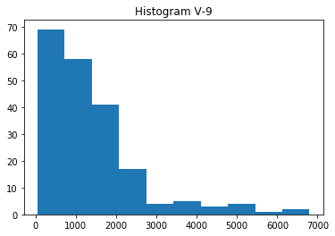

```python
information_table(df2)
```

### Credit Card Data

For more information visit http://archive.ics.uci.edu/ml/datasets/default+of+credit+card+clients.

Purpose: Classification

```python
url='http://archive.ics.uci.edu/ml/machine-learning-databases/00350/default%20of%20credit%20card%20clients.xls'
df3=pd.read_excel(url,skiprows=1, index_col=0)

df3
```

| ID | LIMIT_BAL | SEX | EDUCATION | MARRIAGE | AGE | PAY_0 | PAY_2 | PAY_3 | PAY_4 | PAY_5 | ... | BILL_AMT4 | BILL_AMT5 | BILL_AMT6 | PAY_AMT1 | PAY_AMT2 | PAY_AMT3 | PAY_AMT4 | PAY_AMT5 | PAY_AMT6 | default payment next month |
| --- | --- | --- | --- | --- | --- | --- | --- | --- | --- | --- | --- | --- | --- | --- | --- | --- | --- | --- | --- | --- | --- |
| 1 | 20000 | 2 | 2 | 1 | 24 | 2 | 2 | -1 | -1 | -2 | ... | 0 | 0 | 0 | 0 | 689 | 0 | 0 | 0 | 0 | 1 |
| 2 | 120000 | 2 | 2 | 2 | 26 | -1 | 2 | 0 | 0 | 0 | ... | 3272 | 3455 | 3261 | 0 | 1000 | 1000 | 1000 | 0 | 2000 | 1 |
| 3 | 90000 | 2 | 2 | 2 | 34 | 0 | 0 | 0 | 0 | 0 | ... | 14331 | 14948 | 15549 | 1518 | 1500 | 1000 | 1000 | 1000 | 5000 | 0 |
| 4 | 50000 | 2 | 2 | 1 | 37 | 0 | 0 | 0 | 0 | 0 | ... | 28314 | 28959 | 29547 | 2000 | 2019 | 1200 | 1100 | 1069 | 1000 | 0 |
| 5 | 50000 | 1 | 2 | 1 | 57 | -1 | 0 | -1 | 0 | 0 | ... | 20940 | 19146 | 19131 | 2000 | 36681 | 10000 | 9000 | 689 | 679 | 0 |
| ... | ... | ... | ... | ... | ... | ... | ... | ... | ... | ... | ... | ... | ... | ... | ... | ... | ... | ... | ... | ... | ... |
| 29996 | 220000 | 1 | 3 | 1 | 39 | 0 | 0 | 0 | 0 | 0 | ... | 88004 | 31237 | 15980 | 8500 | 20000 | 5003 | 3047 | 5000 | 1000 | 0 |
| 29997 | 150000 | 1 | 3 | 2 | 43 | -1 | -1 | -1 | -1 | 0 | ... | 8979 | 5190 | 0 | 1837 | 3526 | 8998 | 129 | 0 | 0 | 0 |
| 29998 | 30000 | 1 | 2 | 2 | 37 | 4 | 3 | 2 | -1 | 0 | ... | 20878 | 20582 | 19357 | 0 | 0 | 22000 | 4200 | 2000 | 3100 | 1 |
| 29999 | 80000 | 1 | 3 | 1 | 41 | 1 | -1 | 0 | 0 | 0 | ... | 52774 | 11855 | 48944 | 85900 | 3409 | 1178 | 1926 | 52964 | 1804 | 1 |
| 30000 | 50000 | 1 | 2 | 1 | 46 | 0 | 0 | 0 | 0 | 0 | ... | 36535 | 32428 | 15313 | 2078 | 1800 | 1430 | 1000 | 1000 | 1000 | 1 |

30000 rows × 24 columns

```python
information_table(df3)
```

```
Dataset has 30000 instances and 24 features.
After we train test split;
Training data has 20100 instances and testing data has 9900 instances.
Class Type is Classification.
Data has 23 numeric and 0 object features.
Data has no missing value.
Lets examine imbalance:
```

|  | default payment next month | default payment next month |
| --- | --- | --- |
| 0 | 15599 | 0.77607 |
| 1 | 4501 | 0.22393 |

### Mice Data

For more information visit http://archive.ics.uci.edu/ml/datasets/Mice+Protein+Expression.

Purpose: Multi-Class Classification.

```python
url='http://archive.ics.uci.edu/ml/machine-learning-databases/00342/Data_Cortex_Nuclear.xls'
df4=pd.read_excel(url ,index_col=0)

df4.drop(columns=['Genotype','Treatment','Behavior'],inplace=True)
df4
```

| MouseID | DYRK1A_N | ITSN1_N | BDNF_N | NR1_N | NR2A_N | pAKT_N | pBRAF_N | pCAMKII_N | pCREB_N | pELK_N | ... | BAD_N | BCL2_N | pS6_N | pCFOS_N | SYP_N | H3AcK18_N | EGR1_N | H3MeK4_N | CaNA_N | class |
| --- | --- | --- | --- | --- | --- | --- | --- | --- | --- | --- | --- | --- | --- | --- | --- | --- | --- | --- | --- | --- | --- |
| 309_1 | 0.503644 | 0.747193 | 0.430175 | 2.816329 | 5.990152 | 0.218830 | 0.177565 | 2.373744 | 0.232224 | 1.750936 | ... | 0.122652 | NaN | 0.106305 | 0.108336 | 0.427099 | 0.114783 | 0.131790 | 0.128186 | 1.675652 | c-CS-m |
| 309_2 | 0.514617 | 0.689064 | 0.411770 | 2.789514 | 5.685038 | 0.211636 | 0.172817 | 2.292150 | 0.226972 | 1.596377 | ... | 0.116682 | NaN | 0.106592 | 0.104315 | 0.441581 | 0.111974 | 0.135103 | 0.131119 | 1.743610 | c-CS-m |
| 309_3 | 0.509183 | 0.730247 | 0.418309 | 2.687201 | 5.622059 | 0.209011 | 0.175722 | 2.283337 | 0.230247 | 1.561316 | ... | 0.118508 | NaN | 0.108303 | 0.106219 | 0.435777 | 0.111883 | 0.133362 | 0.127431 | 1.926427 | c-CS-m |
| 309_4 | 0.442107 | 0.617076 | 0.358626 | 2.466947 | 4.979503 | 0.222886 | 0.176463 | 2.152301 | 0.207004 | 1.595086 | ... | 0.132781 | NaN | 0.103184 | 0.111262 | 0.391691 | 0.130405 | 0.147444 | 0.146901 | 1.700563 | c-CS-m |
| 309_5 | 0.434940 | 0.617430 | 0.358802 | 2.365785 | 4.718679 | 0.213106 | 0.173627 | 2.134014 | 0.192158 | 1.504230 | ... | 0.129954 | NaN | 0.104784 | 0.110694 | 0.434154 | 0.118481 | 0.140314 | 0.148380 | 1.839730 | c-CS-m |
| ... | ... | ... | ... | ... | ... | ... | ... | ... | ... | ... | ... | ... | ... | ... | ... | ... | ... | ... | ... | ... | ... |
| J3295_11 | 0.254860 | 0.463591 | 0.254860 | 2.092082 | 2.600035 | 0.211736 | 0.171262 | 2.483740 | 0.207317 | 1.057971 | ... | 0.190483 | NaN | 0.115806 | 0.183324 | 0.374088 | 0.318782 | 0.204660 | 0.328327 | 1.364823 | t-SC-s |
| J3295_12 | 0.272198 | 0.474163 | 0.251638 | 2.161390 | 2.801492 | 0.251274 | 0.182496 | 2.512737 | 0.216339 | 1.081150 | ... | 0.190463 | NaN | 0.113614 | 0.175674 | 0.375259 | 0.325639 | 0.200415 | 0.293435 | 1.364478 | t-SC-s |
| J3295_13 | 0.228700 | 0.395179 | 0.234118 | 1.733184 | 2.220852 | 0.220665 | 0.161435 | 1.989723 | 0.185164 | 0.884342 | ... | 0.216682 | NaN | 0.118948 | 0.158296 | 0.422121 | 0.321306 | 0.229193 | 0.355213 | 1.430825 | t-SC-s |
| J3295_14 | 0.221242 | 0.412894 | 0.243974 | 1.876347 | 2.384088 | 0.208897 | 0.173623 | 2.086028 | 0.192044 | 0.922595 | ... | 0.222263 | NaN | 0.125295 | 0.196296 | 0.397676 | 0.335936 | 0.251317 | 0.365353 | 1.404031 | t-SC-s |
| J3295_15 | 0.302626 | 0.461059 | 0.256564 | 2.092790 | 2.594348 | 0.251001 | 0.191811 | 2.361816 | 0.223632 | 1.064085 | ... | 0.227606 | NaN | 0.118899 | 0.187556 | 0.420347 | 0.335062 | 0.252995 | 0.365278 | 1.370999 | t-SC-s |

1080 rows × 78 columns

```python
information_table(df4)
```

```
Dataset has 1080 instances and 78 features.
After we train test split;
Training data has 723 instances and testing data has 357 instances.
Class Type is Multi-Class Classification.
Data has 77 numeric and 0 object features.
Data has missing value.
Lets examine imbalance:
```

|  | class | class |
| --- | --- | --- |
| c-CS-m | 110 | 0.152144 |
| c-SC-m | 100 | 0.138313 |
| t-SC-m | 96 | 0.132780 |
| c-CS-s | 92 | 0.127248 |
| t-SC-s | 90 | 0.124481 |
| c-SC-s | 88 | 0.121715 |
| t-CS-m | 80 | 0.110650 |
| t-CS-s | 67 | 0.092669 |

```python
dic={'student_performance':df1,'credit_card':df3,'building':df2,'mice':df4}
```

## Preprocess

```python
from sklearn import preprocessing
from sklearn.metrics import mean_squared_error
from sklearn.metrics import roc_auc_score
from sklearn.metrics import f1_score

def preprocess(df):
    y=df.iloc[:,-1]
    y_type=check_type(y)
    if y_type=='Regression':
        stratify=None
    else:
        stratify=y

    x_train, x_test, y_train, y_test = train_test(df,stratify)
    if check_missing_value(x_train):
        x_train=x_train.fillna(x_train.mean())
        x_test=x_test.fillna(x_test.mean())
    if len(object_features(x_train))>0:
        x_train=pd.get_dummies(x_train)
        x_test=pd.get_dummies(x_test)
    y_type=check_type(y_train)
    if y_type=='Multi-Class Classification':
        encoder = preprocessing.LabelEncoder()
        encoder.fit(y_train)
        y_train = encoder.transform(y_train)
        y_test = encoder.transform(y_test)
    return x_train, x_test, y_train, y_test
```

# Models

In this section, we initialize all the models that we will use. We will set some candidate values for each model's parameters. Finally, we define some functions which will help us to make some prediction and obtain performance scores in the future.

## Penalized Regression Approaches

```python
from sklearn.linear_model import ElasticNet
from sklearn.linear_model import SGDClassifier

def penalized_reg(alpha_number=6):
    model=ElasticNet(random_state=0)
    alpha = np.logspace(-2, 3, alpha_number)
    l1_ratio = np.linspace(0,1,5)

    tune_params = [{'alpha': alpha,
                   'l1_ratio': l1_ratio}]

    return model, tune_params

def penalized_reg_test_score(params,df):
    x_train, x_test, y_train, y_test = preprocess(df)
    model=ElasticNet(random_state=0)
    model.set_params(**params)
    model=model.fit(x_train,y_train)
    pred_train=model.predict(x_train)
    pred_test=model.predict(x_test)
    train_mse=mean_squared_error(y_train,pred_train)*-1
    test_mse=mean_squared_error(y_test,pred_test)*-1
    print('Training Negative Mean Squared Error score is ' + str(train_mse))
    print('Testing Negative Mean Squared Error score is ' + str(test_mse))
    return test_mse

def penalized_class(alpha_number=6):
    model=SGDClassifier(penalty='elasticnet')
    alpha = np.logspace(-2, 3, alpha_number)
    l1_ratio = np.linspace(0,1,5)

    tune_params = [{'alpha': alpha,
                   'l1_ratio': l1_ratio}]

    return model, tune_params

def penalized_class_test_score(params,df):
    x_train, x_test, y_train, y_test = preprocess(df)
    model=SGDClassifier(random_state=0)
    model.set_params(**params)
    model=model.fit(x_train,y_train)
    pred_train=model.predict(x_train)
    pred_test=model.predict(x_test)
    if check_type(y_train)=='Multi-Class Classification':
        train_f1=f1_score(y_train,pred_train,labels=np.arange(8),average='micro')
        test_f1=f1_score(y_test,pred_test,labels=np.arange(8),average='micro')
        print('Training f1 micro score is ' + str(train_f1))
        print('Testing f1 micro score is ' + str(test_f1))
        return test_f1
    else:
        train_auc=roc_auc_score(y_train,pred_train)
        test_auc=roc_auc_score(y_test,pred_test)
        print('Training ROC AUC score is ' + str(train_auc))
        print('Testing ROC AUC  is ' + str(test_auc))
        return test_auc
```

## Decision Tree

```python
from sklearn.tree import DecisionTreeClassifier
from sklearn.tree import DecisionTreeRegressor

def decision_tree():
    model=DecisionTreeClassifier(random_state=0)

    min_samples_leaf= np.arange(1,7)
    ccp_alpha=np.logspace(-2, 2, 5)

    tune_params = [{'ccp_alpha': ccp_alpha,
                    'min_samples_leaf': min_samples_leaf}]

    return model, tune_params

def regression_tree():
    model=DecisionTreeRegressor(random_state=0)

    min_samples_leaf= np.arange(1,7)
    ccp_alpha=np.logspace(-2, 2, 5)

    tune_params = [{'ccp_alpha': ccp_alpha,
                    'min_samples_leaf': min_samples_leaf}]

    return model, tune_params

def decision_tree_test_score(params,df):
    x_train, x_test, y_train, y_test = preprocess(df)
    model=DecisionTreeClassifier(random_state=0)
    model.set_params(**params)
    model=model.fit(x_train,y_train)
    pred_train=model.predict(x_train)
    pred_test=model.predict(x_test)
    if check_type(y_train)=='Multi-Class Classification':
        train_f1=f1_score(y_train,pred_train,average='micro')
        test_f1=f1_score(y_test,pred_test,average='micro')
        print('Training f1 micro score is ' + str(train_f1))
        print('Testing f1 micro score is ' + str(test_f1))
        return test_f1
    else:
        train_auc=roc_auc_score(y_train,pred_train)
        test_auc=roc_auc_score(y_test,pred_test)
        print('Training ROC AUC score is ' + str(train_auc))
        print('Testing ROC AUC  is ' + str(test_auc))
        return test_auc


def regression_tree_test_score(params,df):
    x_train, x_test, y_train, y_test = preprocess(df)
    model=DecisionTreeRegressor(random_state=0)
    model.set_params(**params)
    model=model.fit(x_train,y_train)
    pred_train=model.predict(x_train)
    pred_test=model.predict(x_test)
    train_mse=mean_squared_error(y_train,pred_train)*-1
    test_mse=mean_squared_error(y_test,pred_test)*-1
    print('Training Negative Mean Squared Error score is ' + str(train_mse))
    print('Testing Negative Mean Squared Error score is ' + str(test_mse))
    return test_mse
```

## Random Forest

```python
from sklearn.ensemble import RandomForestClassifier
from sklearn.ensemble import RandomForestRegressor

def rf_clf(x_train,feature_number=6):
    model=RandomForestClassifier(n_estimators=500, min_samples_leaf=5,random_state=0)

    max_features=np.round(np.linspace(5,x_train.shape[1],feature_number)).astype(int)

    tune_params = [{'max_features': max_features}]

    return model, tune_params

def rf_clf_test_score(params,df):
    x_train, x_test, y_train, y_test = preprocess(df)
    model=RandomForestClassifier(n_estimators=500, min_samples_leaf=5,random_state=0)
    model.set_params(**params)
    model=model.fit(x_train,y_train)
    pred_train=model.predict(x_train)
    pred_test=model.predict(x_test)
    if check_type(y_train)=='Multi-Class Classification':
        train_f1=f1_score(y_train,pred_train,average='micro')
        test_f1=f1_score(y_test,pred_test,average='micro')
        print('Training f1 micro score is ' + str(train_f1))
        print('Testing f1 micro score is ' + str(test_f1))
        return test_f1
    else:
        train_auc=roc_auc_score(y_train,pred_train)
        test_auc=roc_auc_score(y_test,pred_test)
        print('Training ROC AUC score is ' + str(train_auc))
        print('Testing ROC AUC  is ' + str(test_auc))
        return test_auc


def rf_reg(x_train,feature_number=6):
    model=RandomForestRegressor(n_estimators=500, min_samples_leaf=5,random_state=0)

    max_features=np.round(np.linspace(5,x_train.shape[1],feature_number)).astype(int)

    tune_params = [{'max_features': max_features}]

    return model, tune_params

def rf_reg_test_score(params,df):
    x_train, x_test, y_train, y_test = preprocess(df)
    model=RandomForestRegressor(n_estimators=500, min_samples_leaf=5,random_state=0)
    model.set_params(**params)
    model=model.fit(x_train,y_train)
    pred_train=model.predict(x_train)
    pred_test=model.predict(x_test)
    train_mse=mean_squared_error(y_train,pred_train)*-1
    test_mse=mean_squared_error(y_test,pred_test)*-1
    print('Training Negative Mean Squared Error score is ' + str(train_mse))
    print('Testing Negative Mean Squared Error score is ' + str(test_mse))
    return test_mse
```

## Stochastic Gradient Boosting

```python
from sklearn.ensemble import GradientBoostingClassifier
from sklearn.ensemble import GradientBoostingRegressor

def gb_clf(learning_number=4):
    model=GradientBoostingClassifier(min_samples_leaf=10,subsample=0.5,random_state=0)

    learning_rate=np.logspace(-4, -1, learning_number)
    n_estimators=[10,20,50,100,150,200]
    max_depth=[2,3,5,10,20]

    tune_params = [{'learning_rate': learning_rate,
                    'n_estimators' : n_estimators,
                     'max_depth': max_depth}]

    return model, tune_params

def gb_clf_test_score(params,df):
    x_train, x_test, y_train, y_test = preprocess(df)
    model=GradientBoostingClassifier(min_samples_leaf=10,subsample=0.5,random_state=0)
    model.set_params(**params)
    model=model.fit(x_train,y_train)
    pred_train=model.predict(x_train)
    pred_test=model.predict(x_test)
    if check_type(y_train)=='Multi-Class Classification':
        train_f1=f1_score(y_train,pred_train,average='micro')
        test_f1=f1_score(y_test,pred_test,average='micro')
        print('Training f1 micro score is ' + str(train_f1))
        print('Testing f1 micro score is ' + str(test_f1))
        return test_f1
    else:
        train_auc=roc_auc_score(y_train,pred_train)
        test_auc=roc_auc_score(y_test,pred_test)
        print('Training ROC AUC score is ' + str(train_auc))
        print('Testing ROC AUC  is ' + str(test_auc))
        return test_auc


def gb_reg(learning_number=4):
    model=GradientBoostingRegressor(min_samples_leaf=10,subsample=0.5,random_state=0)

    learning_rate=np.logspace(-4, -1, learning_number)
    n_estimators=[10,20,50,100,150,200]
    max_depth=[2,3,5,10,20]

    tune_params = [{'learning_rate': learning_rate,
                    'n_estimators' : n_estimators,
                     'max_depth': max_depth}]

    return model, tune_params

def gb_reg_test_score(params,df):
    x_train, x_test, y_train, y_test = preprocess(df)
    model=GradientBoostingRegressor(min_samples_leaf=10,subsample=0.5,random_state=0)
    model.set_params(**params)
    model=model.fit(x_train,y_train)
    pred_train=model.predict(x_train)
    pred_test=model.predict(x_test)
    train_mse=mean_squared_error(y_train,pred_train)*-1
    test_mse=mean_squared_error(y_test,pred_test)*-1
    print('Training Negative Mean Squared Error score is ' + str(train_mse))
    print('Testing Negative Mean Squared Error score is ' + str(test_mse))
    return test_mse
```

# Parameter Tuning and Cross Validation

In this section, we will perform cross validation in order to build a strong model. We will use gridsearchcv method to be able to find good parameters for our model and we interpret our findings. We will follow the steps mentioned below:

- We will perform gridsearchcv for predefined set of parameters in the previous section.
- This will resulted with lots of candidate parameter with performance scores.
- We won't select parameters with the highest score,
- Instead we will groupby each parameter with respect to its values and calculate the mean of the performance score (training and validation) for the grouped values
- This way we will be able to discover the real relationship between the parameters.
- We will select an arbitrary parameters.
- Then we will fit the candidate and measure performance score on testing data.
- We plot everything in a graph. (cross validation scores of each parameter group on training, validation data and performance of testing data)
- Finally we will readjust the candidate solution to optimal one.

Lets define some functions:

```python
from sklearn.model_selection import GridSearchCV

def cross_validate(x_train,y_train,model,tune_params,cv):
    y_type = check_type(y_train)
    if y_type == 'Regression':
        cross_validate = GridSearchCV(model,tune_params,scoring='neg_mean_squared_error',cv=cv,return_train_score=True,n_jobs=-2)
        cross_validate_fit=cross_validate.fit(x_train,y_train)
    elif y_type == 'Classification':
        cross_validate = GridSearchCV(model,tune_params,scoring='roc_auc',cv=cv,return_train_score=True,n_jobs=-2)
        cross_validate_fit=cross_validate.fit(x_train,y_train)
    else:
        cross_validate = GridSearchCV(model,tune_params,scoring='f1_micro',cv=cv,return_train_score=True,n_jobs=-2)
        cross_validate_fit=cross_validate.fit(x_train,y_train)
    return cross_validate_fit.cv_results_


def perform_cv(dic,cv):
    combined_dict={}

    for k,v in dic.items():
        new_dict={}
        x_train, x_test, y_train, y_test = preprocess(v)

        y_type = check_type(y_train)
        if y_type != 'Regression':
            model,tune_params= penalized_class()
            name = str(model).split('(')[0]
            new_dict.update({name:cross_validate(x_train,y_train,model,tune_params,cv)})


            model,tune_params= decision_tree()
            name = str(model).split('(')[0]
            new_dict.update({name:cross_validate(x_train,y_train,model,tune_params,cv)})

            model,tune_params=rf_clf(x_train)
            name = str(model).split('(')[0]
            new_dict.update({name:cross_validate(x_train,y_train,model,tune_params,cv)})

            model,tune_params=gb_clf()
            name = str(model).split('(')[0]
            new_dict.update({name:cross_validate(x_train,y_train,model,tune_params,cv)})

        else:
            model,tune_params= penalized_reg()
            name = str(model).split('(')[0]
            new_dict.update({name:cross_validate(x_train,y_train,model,tune_params,cv)})


            model,tune_params= regression_tree()
            name = str(model).split('(')[0]
            new_dict.update({name:cross_validate(x_train,y_train,model,tune_params,cv)})

            model,tune_params=rf_reg(x_train)
            name = str(model).split('(')[0]
            new_dict.update({name:cross_validate(x_train,y_train,model,tune_params,cv)})

            model,tune_params=gb_reg()
            name = str(model).split('(')[0]
            new_dict.update({name:cross_validate(x_train,y_train,model,tune_params,cv)})

        combined_dict.update({k:new_dict})
    return combined_dict


combined_dict=perform_cv(dic,5)
```

```python
def filter_columns(df,name):
    return [col for col in df if col.startswith(name)]

def check_lenght(list1):
    return len(list1)

def groupby_wrt_param(combined_dict):
    dic1={}
    for k1,v1 in combined_dict.items():
        dic2={}
        for k2, v2, in v1.items():
            list1=filter_columns(v2,'param_')
            len_list1=check_lenght(list1)
            list1.append('mean_test_score')
            list1.append('mean_train_score')
            df=pd.DataFrame.from_dict(v2)[list1]
            if len_list1==1:
                grouped=df.groupby([df[list1[0]]]).agg({'mean_test_score':'mean','mean_train_score':'mean'})
                dic2.update({k2:[grouped]})

            elif len_list1==2:
                grouped1=df.groupby([df[list1[0]]]).agg({'mean_test_score':'mean','mean_train_score':'mean'})
                grouped2=df.groupby([df[list1[1]]]).agg({'mean_test_score':'mean','mean_train_score':'mean'})
                dic2.update({k2:[grouped1,grouped2]})

            elif len_list1==3:
                grouped1=df.groupby([df[list1[0]]]).agg({'mean_test_score':'mean','mean_train_score':'mean'})
                grouped2=df.groupby([df[list1[1]]]).agg({'mean_test_score':'mean','mean_train_score':'mean'})
                grouped3=df.groupby([df[list1[2]]]).agg({'mean_test_score':'mean','mean_train_score':'mean'})
                dic2.update({k2:[grouped1,grouped2,grouped3]})
        dic1.update({k1:dic2})
    return dic1

grouped = groupby_wrt_param(combined_dict)

def get_dataset(grouped,dataset_name):
    return grouped[dataset_name]

def get_data(grouped,dataset_name,model_name):
    dic=get_dataset(grouped,dataset_name)
    return dic[model_name]
```

```python
def cv_plot(test_score,list1,title): #this function enables us to plot cv_scores wrt parameters we selected

    c1='orange'
    c2='grey'
    c3='navy'


    fig, host = plt.subplots(figsize=(8,5)) # (width, height) in inches

    fig.suptitle(title, y=1.05)

    if len(list1)==1:
        p1, = host.plot(list1[0]['mean_test_score'],list1[0].index.values,color=c1, label='validation '+list1[0].index.name)
        p1, = host.plot(list1[0]['mean_train_score'],list1[0].index.values,color=c1, linestyle='dashed', marker='+',label='train '+list1[0].index.name)

        host.set_xlabel("Performance")
        host.set_ylabel(list1[0].index.name)

    if len(list1)==2:

        par1 = host.twinx()

        p1, = host.semilogy(list1[0]['mean_test_score'],list1[0].index.values,color=c1, label='validation '+list1[0].index.name)
        p1, = host.semilogy(list1[0]['mean_train_score'],list1[0].index.values,color=c1, linestyle='dashed', marker='+',label='train '+list1[0].index.name)

        p2, = par1.plot(list1[1]['mean_test_score'],list1[1].index.values,color=c2, label='validation '+list1[1].index.name)
        p2, = par1.plot(list1[1]['mean_train_score'],list1[1].index.values,color=c2, linestyle='dashed', marker='+',label='train '+list1[1].index.name)

        host.set_xlabel("Performance")
        host.set_ylabel(list1[0].index.name)
        par1.set_ylabel(list1[1].index.name)

    if len(list1)==3:

        par1 = host.twinx()
        par2 = host.twinx()

        p1, = host.plot(list1[0]['mean_test_score'],list1[0].index.values,color=c1, label='validation '+list1[0].index.name)
        p1, = host.plot(list1[0]['mean_train_score'],list1[0].index.values,color=c1, linestyle='dashed', marker='+', label='train '+list1[0].index.name)

        p2, = par1.plot(list1[1]['mean_test_score'],list1[1].index.values,color=c2, label='validation '+list1[1].index.name)
        p2, = par1.plot(list1[1]['mean_train_score'],list1[1].index.values,color=c2, linestyle='dashed', marker='+', label='train '+list1[1].index.name)

        p3, = par2.plot(list1[2]['mean_test_score'],list1[2].index.values,color=c3,  label='validation '+list1[2].index.name)
        p3, = par2.plot(list1[2]['mean_train_score'],list1[2].index.values,color=c3, linestyle='dashed', marker='+', label='train '+list1[2].index.name)

        host.set_xlabel("Performance")
        host.set_ylabel(list1[0].index.name)
        par1.set_ylabel(list1[1].index.name)
        par2.set_ylabel(list1[2].index.name)

        par2.spines['right'].set_position(('outward', 60))

    host.axvline(test_score, color='red', linestyle='dotted', label='test score')
    plt.grid()
    fig.legend(bbox_to_anchor=(1.05, 1), loc=2)
    fig.tight_layout()
```

We defined all the necessary functions to evaluate CV scores. Now we need to examine each dataset one by one.

```python
all_performance_dict={}
```

## Students Performance Data

```python
model_performance_dict={}
```

### Penalized Regression

```
Training Negative Mean Squared Error score is -1.627747948394752
Testing Negative Mean Squared Error score is -1.600090445690735
```

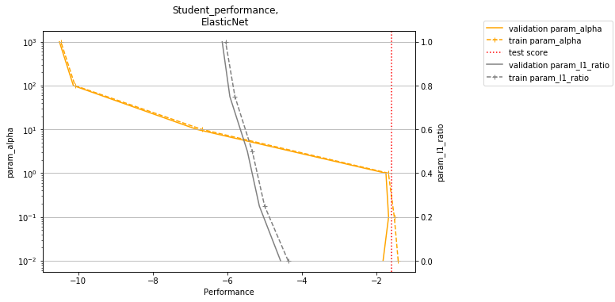

```python
model_name='ElasticNet'
dataset_name='student_performance'

alpha=10**0
l1_ratio=0
params={'alpha':alpha,
        'l1_ratio':l1_ratio}

test_score=penalized_reg_test_score(params,df1)

cv_plot(test_score,get_data(grouped,dataset_name,model_name),dataset_name.capitalize() + ',\n' + model_name)


model_performance_dict.update({model_name:test_score})
```

### Decision Tree

```
Training Negative Mean Squared Error score is -1.4717552091972508
Testing Negative Mean Squared Error score is -2.142744628790969
```

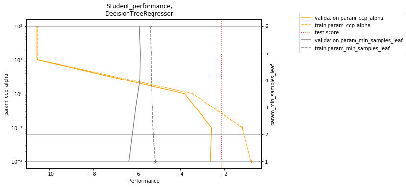

```python
model_name='DecisionTreeRegressor'
dataset_name='student_performance'

ccp_alpha=10**-1
min_samples_leaf=4

params = {'ccp_alpha': ccp_alpha,
           'min_samples_leaf': min_samples_leaf}

test_score=regression_tree_test_score(params,df1)

cv_plot(test_score,get_data(grouped,dataset_name,model_name),dataset_name.capitalize() + ',\n' + model_name)

model_performance_dict.update({model_name:test_score})
```

### Random Forest

```
Training Negative Mean Squared Error score is -0.9143230599445953
Testing Negative Mean Squared Error score is -1.7586067331256676
```

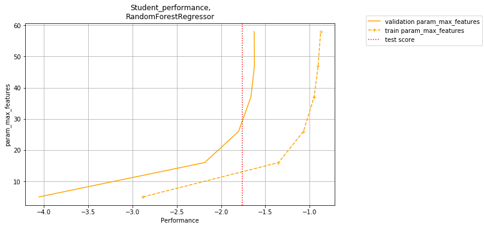

```python
model_name='RandomForestRegressor'
dataset_name='student_performance'

params={'max_features':35}

test_score=rf_reg_test_score(params,df1)

cv_plot(test_score,get_data(grouped,dataset_name,model_name),dataset_name.capitalize() + ',\n' + model_name)

model_performance_dict.update({model_name:test_score})
```

### Stochastic Gradient Boosting

```
Training Negative Mean Squared Error score is -0.6758710029298762
Testing Negative Mean Squared Error score is -2.1501850555671513
```

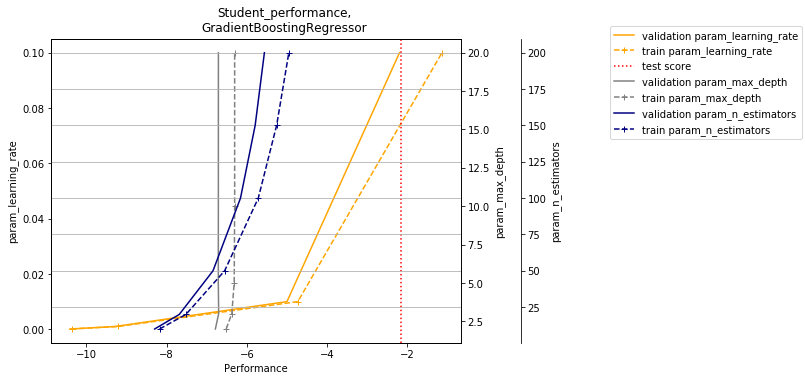

```python
model_name='GradientBoostingRegressor'
dataset_name='student_performance'

max_depth=3
learning_rate=0.1
n_estimators=100

params={'max_depth':max_depth,
        'learning_rate':learning_rate,
        'n_estimators':n_estimators}

test_score=gb_reg_test_score(params,df1)

cv_plot(test_score,get_data(grouped,dataset_name,model_name),dataset_name.capitalize() + ',\n' + model_name)

model_performance_dict.update({model_name:test_score})
all_performance_dict.update({dataset_name:model_performance_dict})
```

## Residential Building Data

### Penalized Regression

```
Training Negative Mean Squared Error score is -18256.029434759614
Testing Negative Mean Squared Error score is -39278.31707467761
```

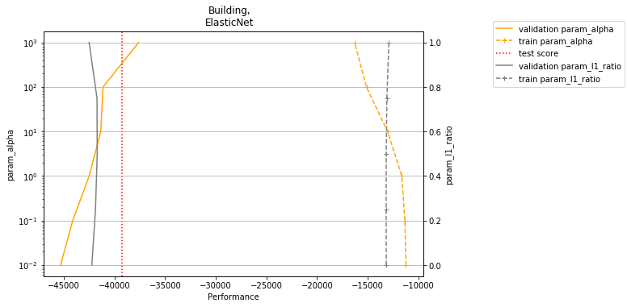

```python
model_name='ElasticNet'
dataset_name='building'

alpha=10**3
l1_ratio=0.6
params={'alpha':alpha,
        'l1_ratio':l1_ratio}

test_score=penalized_reg_test_score(params,df2)

cv_plot(test_score,get_data(grouped,dataset_name,model_name),dataset_name.capitalize() + ',\n' + model_name)

model_performance_dict={}
model_performance_dict.update({model_name:test_score})
```

### Decision Tree

```
Training Negative Mean Squared Error score is -14774.103349673203
Testing Negative Mean Squared Error score is -99171.16691468253
```

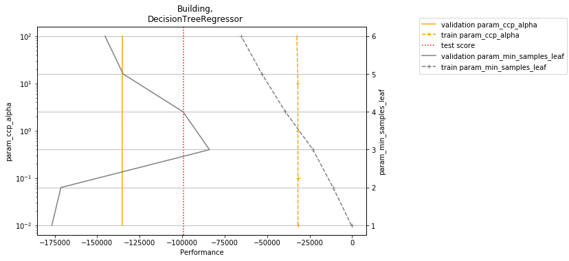

```python
model_name='DecisionTreeRegressor'
dataset_name='building'

ccp_alpha=0
min_samples_leaf=3

params = {'ccp_alpha': ccp_alpha,
           'min_samples_leaf': min_samples_leaf}

test_score=regression_tree_test_score(params,df2)

cv_plot(test_score,get_data(grouped,dataset_name,model_name),dataset_name.capitalize() + ',\n' + model_name)

model_performance_dict.update({model_name:test_score})
```

### Random Forest

```
Training Negative Mean Squared Error score is -51736.77845598722
Testing Negative Mean Squared Error score is -59179.315997952086
```

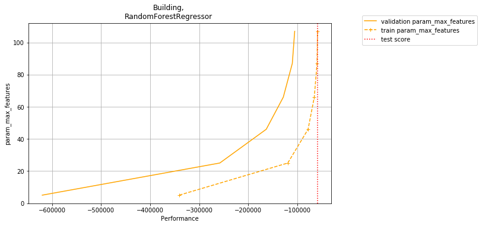

```python
model_name='RandomForestRegressor'
dataset_name='building'

params={'max_features':70}

test_score=rf_reg_test_score(params,df2)

cv_plot(test_score,get_data(grouped,dataset_name,model_name),dataset_name.capitalize() + ',\n' + model_name)

model_performance_dict.update({model_name:test_score})
```

### Stochastic Gradient Boosting

```
Training Negative Mean Squared Error score is -22101.799409447565
Testing Negative Mean Squared Error score is -51154.10831506326
```

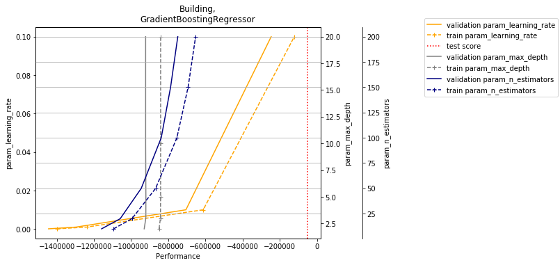

```python
model_name='GradientBoostingRegressor'
dataset_name='building'

max_depth=3
learning_rate=0.1
n_estimators=200

params={'max_depth':max_depth,
        'learning_rate':learning_rate,
        'n_estimators':n_estimators}

test_score=gb_reg_test_score(params,df2)

cv_plot(test_score,get_data(grouped,dataset_name,model_name),dataset_name.capitalize() + ',\n' + model_name)

model_performance_dict.update({model_name:test_score})
all_performance_dict.update({dataset_name:model_performance_dict})
```

## Credit Card Data

### Penalized Regression

```
Training ROC AUC score is 0.5
Testing ROC AUC  is 0.5002283105022831
```

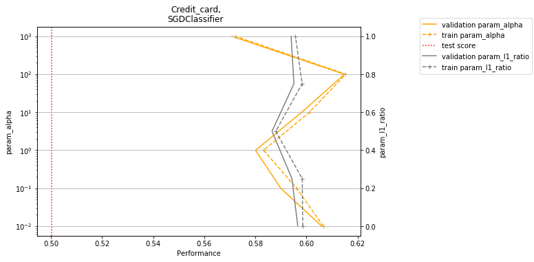

```python
model_name='SGDClassifier'
dataset_name='credit_card'

alpha=10**2
l1_ratio=0.7
params={'alpha':alpha,
        'l1_ratio':l1_ratio}

test_score=penalized_class_test_score(params,df3)

cv_plot(test_score,get_data(grouped,dataset_name,model_name),dataset_name.capitalize() + ',\n' + model_name)

model_performance_dict={}
model_performance_dict.update({model_name:test_score})
```

### Decision Tree

```
Training ROC AUC score is 0.6431089862128171
Testing ROC AUC  is 0.6447026633264041
```

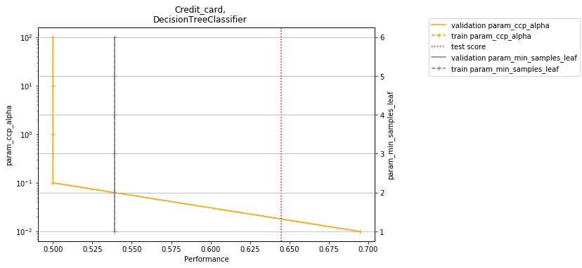

```python
model_name='DecisionTreeClassifier'
dataset_name='credit_card'

ccp_alpha=10**-2
min_samples_leaf=4

params = {'ccp_alpha': ccp_alpha,
           'min_samples_leaf': min_samples_leaf}
test_score=decision_tree_test_score(params,df3)

cv_plot(test_score,get_data(grouped,dataset_name,model_name),dataset_name.capitalize() + ',\n' + model_name)

model_performance_dict.update({model_name:test_score})
```

### Random Forest

```
Training ROC AUC score is 0.7601668900361684
Testing ROC AUC  is 0.6547207860277525
```

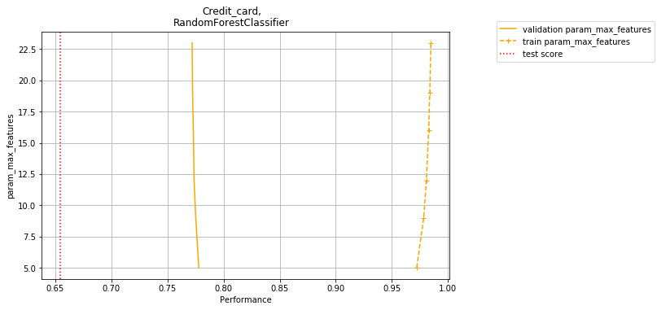

```python
model_name='RandomForestClassifier'
dataset_name='credit_card'

params={'max_features':5}

test_score=rf_clf_test_score(params,df3)

cv_plot(test_score,get_data(grouped,dataset_name,model_name),dataset_name.capitalize() + ',\n' + model_name)

model_performance_dict.update({model_name:test_score})
```

### Stochastic Gradient Boosting

```
Training ROC AUC score is 0.6928877547132173
Testing ROC AUC  is 0.6558650036423076
```

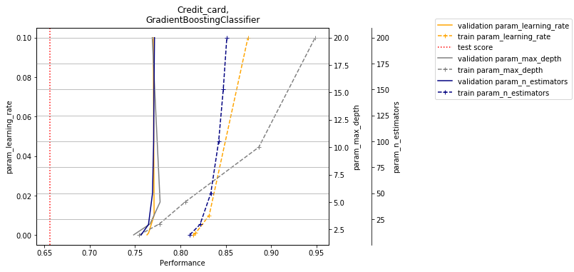

```python
model_name='GradientBoostingClassifier'
dataset_name='credit_card'


max_depth=6
learning_rate=0.1
n_estimators=40

params={'max_depth':max_depth,
        'learning_rate':learning_rate,
        'n_estimators':n_estimators}

test_score=gb_clf_test_score(params,df3)

cv_plot(test_score,get_data(grouped,dataset_name,model_name),dataset_name.capitalize() + ',\n' + model_name)

model_performance_dict.update({model_name:test_score})
all_performance_dict.update({dataset_name:model_performance_dict})
```

## Mice Data

### Penalized Regression

```
Training f1 micro score is 0.7634854771784232
Testing f1 micro score is 0.7254901960784313
```

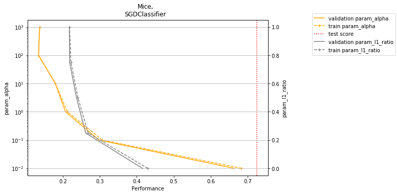

```python
model_name='SGDClassifier'
dataset_name='mice'


alpha=10**-2
l1_ratio=0
params={'alpha':alpha,
        'l1_ratio':l1_ratio}

test_score=penalized_class_test_score(params,df4)

cv_plot(test_score,get_data(grouped,dataset_name,model_name),dataset_name.capitalize() + ',\n' + model_name)

model_performance_dict={}
model_performance_dict.update({model_name:test_score})
```

### Decision Tree

```
Training f1 micro score is 0.8824343015214384
Testing f1 micro score is 0.7535014005602241
```

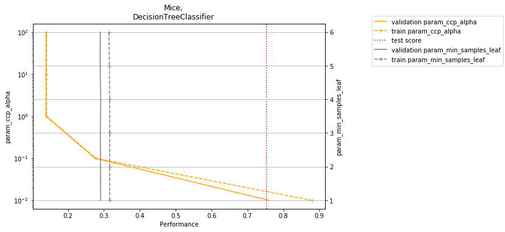

```python
model_name='DecisionTreeClassifier'
dataset_name='mice'

ccp_alpha=10**-2
min_samples_leaf=4

params = {'ccp_alpha': ccp_alpha,
           'min_samples_leaf': min_samples_leaf}

test_score=decision_tree_test_score(params,df4)

cv_plot(test_score,get_data(grouped,dataset_name,model_name),dataset_name.capitalize() + ',\n' + model_name)

model_performance_dict.update({model_name:test_score})
```

### Random Forest

```
Training f1 micro score is 1.0
Testing f1 micro score is 0.9663865546218487
```

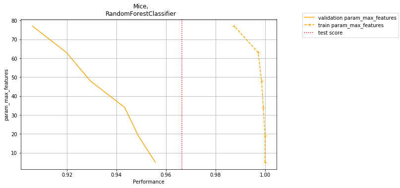

```python
model_name='RandomForestClassifier'
dataset_name='mice'

params={'max_features':5}

test_score=rf_clf_test_score(params,df4)

cv_plot(test_score,get_data(grouped,dataset_name,model_name),dataset_name.capitalize() + ',\n' + model_name)

model_performance_dict.update({model_name:test_score})
```

### Stochastic Gradient Boosting

```
Training f1 micro score is 1.0
Testing f1 micro score is 0.9859943977591037
```

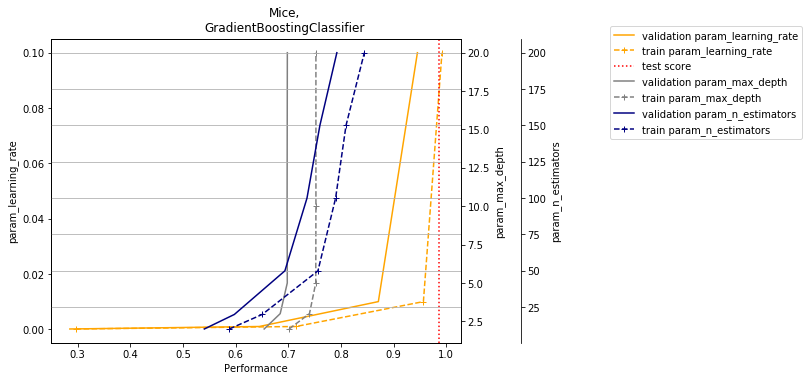

```python
model_name='GradientBoostingClassifier'
dataset_name='mice'

max_depth=5
learning_rate=0.1
n_estimators=150

params={'max_depth':max_depth,
        'learning_rate':learning_rate,
        'n_estimators':n_estimators}

test_score=gb_clf_test_score(params,df4)
cv_plot(test_score,get_data(grouped,dataset_name,model_name),dataset_name.capitalize() + ',\n' + model_name)

model_performance_dict.update({model_name:test_score})
all_performance_dict.update({dataset_name:model_performance_dict})
```

# General Evaluation

```python
pd.DataFrame.from_dict(all_performance_dict)
```

|  | student_performance | building | credit_card | mice |
| --- | --- | --- | --- | --- |
| ElasticNet | -1.600090 | -39278.317075 | NaN | NaN |
| DecisionTreeRegressor | -2.142745 | -99171.166915 | NaN | NaN |
| RandomForestRegressor | -1.758607 | -59179.315998 | NaN | NaN |
| GradientBoostingRegressor | -2.150185 | -51154.108315 | NaN | NaN |
| SGDClassifier | NaN | NaN | 0.500228 | 0.725490 |
| DecisionTreeClassifier | NaN | NaN | 0.644703 | 0.753501 |
| RandomForestClassifier | NaN | NaN | 0.654721 | 0.966387 |
| GradientBoostingClassifier | NaN | NaN | 0.655865 | 0.985994 |

There are four options:

- Performing good
- Overfitted
- Underfitted
- Not performing good

If we briefly explain these option:

If our training data give good scores but the test data give much worse scores compare to training data, it means that model overfitted to data. In other words, the model learning too specific pattern for the given data we cannot generalize it to other data.

If both training and test data give bad results, this means that either the model is underfitted or the model is not suitable for the given data. To solve the underfitting issue we can further tune the model's parameters. For instance max iteration number for elasticnet and sgdclassifier.

The ranking of the models for each dataset is given below;

```python
def ranking(all_performance_dict,dataset,criteria):
    df=pd.DataFrame.from_dict(all_performance_dict[dataset],orient='index')
    df.columns=[criteria]
    df.sort_values([criteria],ascending=False,inplace=True)
    df['Rank']=[1,2,3,4]
    return df
```

```python
ranking(all_performance_dict,'student_performance','Negative Mean Square Error')
```

|  | Negative Mean Square Error | Rank |
| --- | --- | --- |
| ElasticNet | -1.600090 | 1 |
| RandomForestRegressor | -1.758607 | 2 |
| DecisionTreeRegressor | -2.142745 | 3 |
| GradientBoostingRegressor | -2.150185 | 4 |

```python
ranking(all_performance_dict,'building','Negative Mean Square Error')
```

|  | Negative Mean Square Error | Rank |
| --- | --- | --- |
| ElasticNet | -39278.317075 | 1 |
| GradientBoostingRegressor | -51154.108315 | 2 |
| RandomForestRegressor | -59179.315998 | 3 |
| DecisionTreeRegressor | -99171.166915 | 4 |

```python
ranking(all_performance_dict,'credit_card','ROC AUC')
```

|  | ROC AUC | Rank |
| --- | --- | --- |
| GradientBoostingClassifier | 0.655865 | 1 |
| RandomForestClassifier | 0.654721 | 2 |
| DecisionTreeClassifier | 0.644703 | 3 |
| SGDClassifier | 0.500228 | 4 |

```python
ranking(all_performance_dict,'mice','F1 Micro')
```

|  | F1 Micro | Rank |
| --- | --- | --- |
| GradientBoostingClassifier | 0.985994 | 1 |
| RandomForestClassifier | 0.966387 | 2 |
| DecisionTreeClassifier | 0.753501 | 3 |
| SGDClassifier | 0.725490 | 4 |

For the selected datasets, penalized regression approaches perform better compare to tree based methods in regression tasks. Similarly tree based methods perform much better in classification tasks.